# Quality Assessment and Trimming Loggerhead Data

# Assess Raw Read Quality

## Evaluate raw sequence quality

Let’s see the quality of the raw reads *before* we trim

## Plot 12 random samples of plots

```r
# Randomly select 12 samples from dataset to evaluate
# Selecting 12 is typically better than 2 (like we did in class for efficiency)
random_samples <- sample(1:length(reverse_reads), size = 12)
random_samples
```

```
##  [1] 40 45 49 16 39 28 51  4  8 43  5 30
```

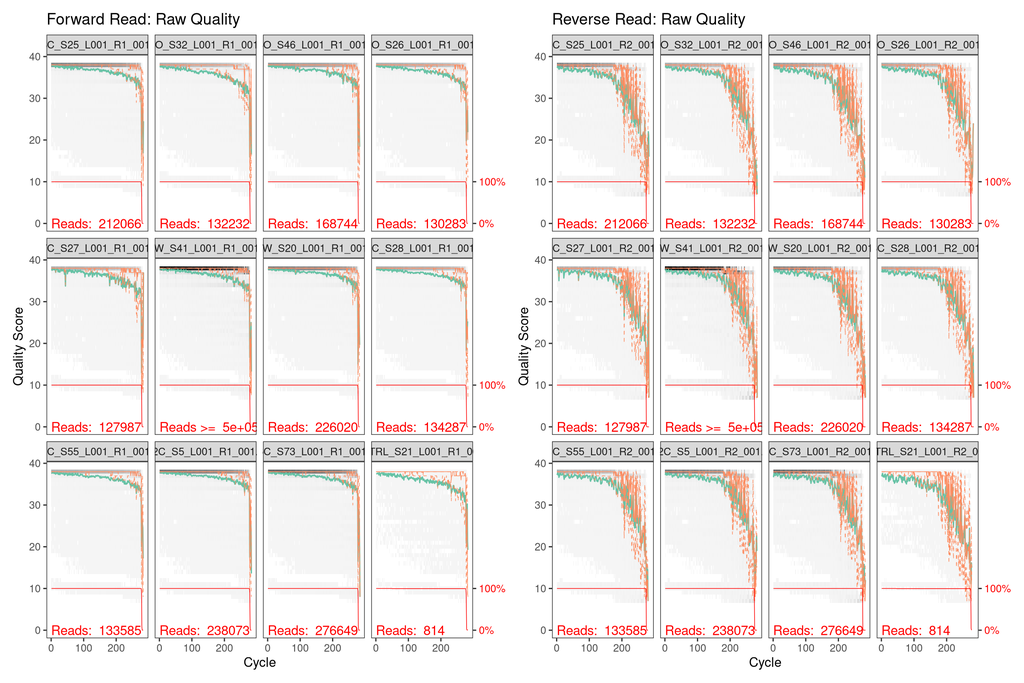

```r
# Calculate and plot quality of these two samples
forward_filteredQual_plot_12 <- plotQualityProfile(forward_reads[random_samples]) +
  guides(fill = "none") +
  labs(title = "Forward Read: Raw Quality")
reverse_filteredQual_plot_12 <- plotQualityProfile(reverse_reads[random_samples]) +
  guides(fill = "none") +
  labs(title = "Reverse Read: Raw Quality")

# Plot them together with patchwork
forward_filteredQual_plot_12 + reverse_filteredQual_plot_12
```

**Acceptable Phred Scores for ASVs with DADA2**

In DADA2, quality filtering is crucial for obtaining reliable biological sequences. Below are the acceptable **Phred score** thresholds for DADA2 preprocessing:

| **Q Score** | **Error Probability** | **DADA2 Interpretation** |
| --- | --- | --- |
| **40** | 0.0001 (1 in 10,000) | Very high-quality , dream come true |
| **≥30** | ≤ 0.001 (1 in 1,000) | Excellent quality, keep |
| **25-30** | ~0.003 - 0.01 | Can be acceptable, but more important to trim low-quality tails |
| **20-25** | ~0.01 - 0.03 | Lower quality, only acceptable if read length is absolutely critical |
| **<20** | > 0.01 (1 in 100) | Poor quality, remove |
| **<10** | >0.1 (1 in 10) | Very unreliable, absolutely remove |

Some summary take-aways:

- **30 is good** – Bases with Q30+ scores have a **99.9% accuracy rate**, making them highly reliable.
- **25-30 can be acceptable**, but trimming is preferred to remove low-quality tails.
- **20-25** should only be kept if read length is absolutely critical (*e.g.* to ensure forward & reverse read overlap)
- **<20 discarded** – Bases with Phred scores below 20 have an **error rate >1%** and should 100% be **trimmed from the dataset**.

Remember, every base counts when we assign ASVs, they are called **sequence variants** for a reason! And, we want to be sure. :)